# Effects of User Type on Bike Use in the Ford GoBike Sharing System

## by Chisom Urom

## Investigation Overview

In this investigation, I looked at the features affecting the rate of bike use in the Ford GoBike Sharing System. The focus attributes were the user-type, duration per ride, the time of day and the day of the week.

## Dataset Overview

The dataset consisted of 174, 952 individual bike rides to and from different stations with 9 variables describing the features of the each ride. The variables include the birth year of the user, user-type, date and time of each ride, start and end station names, bike id and user gender.

The dataset was also divided into two tables to conform with tidiness standards. The `trip` table contains information on the each trip taken by a user, while the `user` table carries information about the user on each trip. 8, 460 rows were dropped due to missing values.

## User Population by Types

Subscribers were the most number of users on the bike share system by a head count. Subscribers were infact more than 5 times the number of Customer type users that used the bikes. This takes into account just the number of trips each user type made with the bike.

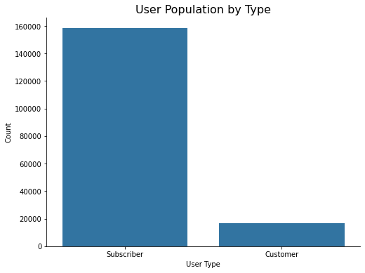

## Distribution of Trip Duration

Each trip duration was measured in seconds and took on quite a wide range of values. The duration ranged from around 60 seconds at its lowest to above to 80, 000 seconds for the highest durations. Plotted on a logarithmic scale, the distribution of duration takes a unimodal shape.

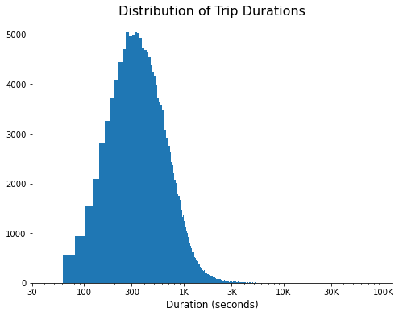

## Average Duration by User type

Customers had a higher duration of use against Subscribers on average. This happens despite the Subscriber population being far greater than the Customers.

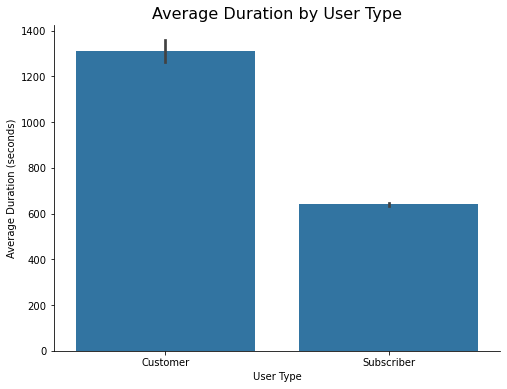

## Daily Use for User Type per Week

Subscribers apparently had the higher amount of use for each day of the week, but the pattern seemed to decline rapidly over the weekends. Thursday was the most active day of the week among both user types, but Customers did not experience the sharp decline weekend activity as did Subscribers. This pattern among subscribers suggest dedicated use of the bike share system for specific purposes on weekdays such as work.

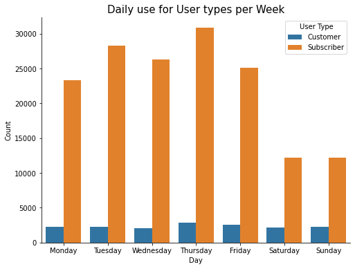

## Hour of Day by User type

The peak hours of bike usage are clearly shown to be around the 8th and 17th hours of the day in a 24 hour time order. The busiest hour was the 17th hour of the day, which reinforces the suggestion that more sunscribers were used the bike share system to cummute to work. Customers shared a similar pattern of hourly usage, but had a more uniform variation than Subscrbers during off-peak hours. The amount of usage declined steadily beyond the 20th hour and was rarely used in the first 5 hour of the day.

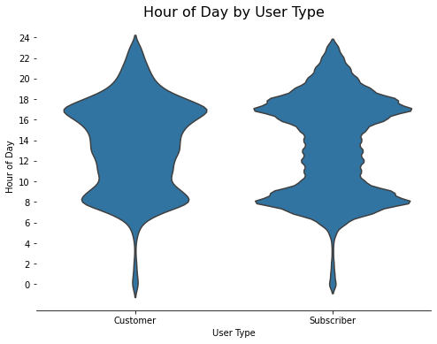

## Gender and Age by User type

Gender and age seemed to have a surface influence on the overall usage of the bike share system. Neither gender nor age had a pronounced impact on whether users chose to Subscribe or not. Generally, there were more males than any other gender, but the proportion of Subscribed males to Customers in the male gender was similar to the proportion across the other genders. Also, younger people around the ages 20 to 60 made up the user population and didn't directly favor the choice of a user to subscribe.

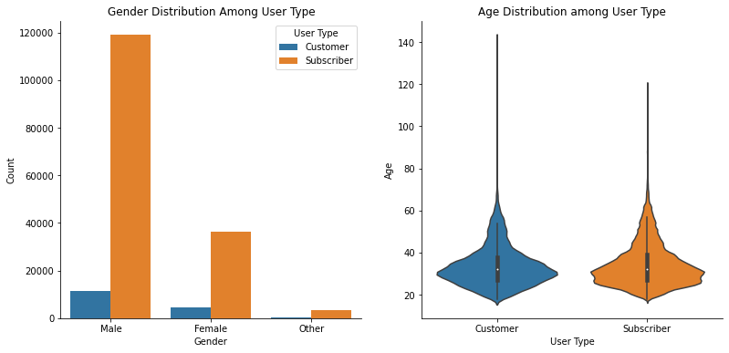

## Hour of Day by Day of Week and User type

It is also evident how Cutomers have more use during off peak hours on week day than Subscribers.

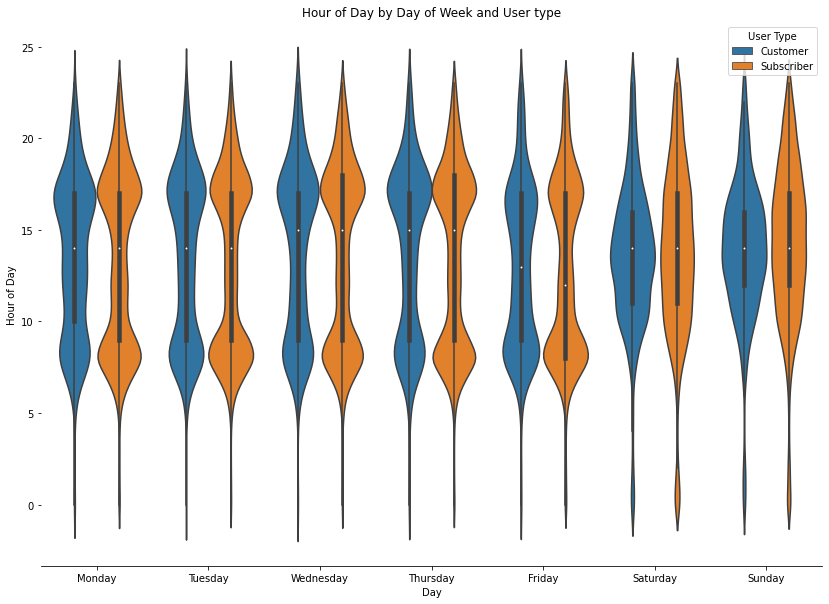

## Day of Week by Ride Duration and User Type

This shows that Subcribers took most of their trips during the weekdays, but more importantly, Subscribers had more medium and short duration trips than long ones. I categorized the trip durations into three groups in the following order:

- Miniumum duration to first quartile = `Short`
- First Quartile to third quartile = `Medium`
- Third quartile to maximum duration = `Long`

While Customer type users mostly used the bike share system for medium and long duration trips, there wasn't however a decline during the weekend. Rather, either day in the weekend had more long duration trips than any other weekday. Thursday remained the busiest day in the week for both user types. The impact of longer duration trips by more Customers and shorter durations by more Subscirbers indicates the reason for Customers having a higher trip duration on average.

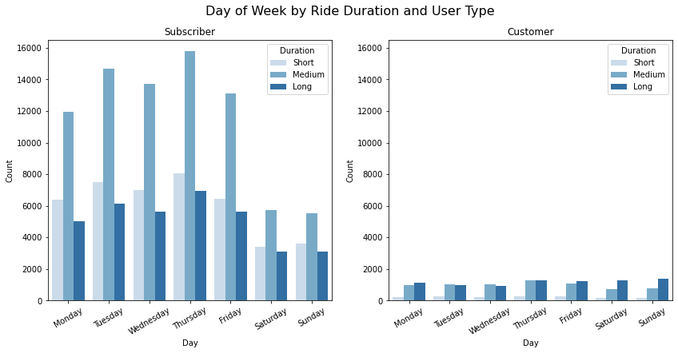